# NYPD

Dominic Maranta

2023-10-03

# NYPD Shooting Dataset

### Introduction

This data analysis project will go through the data science project steps as an exploratory analysis of the NYPD historical shooting incidents data set. This project will first examine and clean the data set and then perfrom several analyses including visuals. This project will also examine possible data bias issues.

```r
#library necessary packages
library(tidyverse)
library(tidyr)
library(broom)
library(ggmap)
library(httr)
library(rgdal)
```

## Reading in the Data

```r
nypd <- read_csv("https://data.cityofnewyork.us/api/views/833y-fsy8/rows.csv?accessType=DOWNLOAD")#read in the data
#summary(nypd)#summary of our data types
```

## Cleaning Data

```r
#head(nypd)

nypd <- nypd %>%#factoring and creating correct data types
  mutate(
    INCIDENT_KEY = factor(INCIDENT_KEY),
    OCCUR_DATE = as.Date(OCCUR_DATE, format="%m/%d/%Y"),
    PRECINCT = factor(PRECINCT),
    JURISDICTION_CODE = factor(JURISDICTION_CODE),
    PERP_AGE_GROUP = factor(PERP_AGE_GROUP),
    PERP_SEX = factor(PERP_SEX),
    PERP_RACE = factor(PERP_RACE),
    VIC_AGE_GROUP = factor(VIC_AGE_GROUP),
    VIC_SEX = factor(VIC_SEX),
    VIC_RACE = factor(VIC_RACE)
  )

nypd <- nypd %>%#keeping relevant variables
  select(
    INCIDENT_KEY, OCCUR_DATE, OCCUR_TIME, PRECINCT, JURISDICTION_CODE, STATISTICAL_MURDER_FLAG, PERP_AGE_GROUP, PERP_SEX, PERP_RACE, VIC_AGE_GROUP, VIC_SEX, VIC_RACE, Latitude, Longitude
  )
head(nypd)#these two lines confirm our data was correctly formatted
```

```
## # A tibble: 6 × 14
##   INCIDENT_KEY OCCUR_DATE OCCUR_TIME PRECINCT JURISDICTION_CODE STATISTICAL_MUR…
##   <fct>        <date>     <time>     <fct>    <fct>             <lgl>
## 1 228798151    2021-05-27 21:30      105      0                 FALSE
## 2 137471050    2014-06-27 17:40      40       0                 FALSE
## 3 147998800    2015-11-21 03:56      108      0                 TRUE
## 4 146837977    2015-10-09 18:30      44       0                 FALSE
## 5 58921844     2009-02-19 22:58      47       0                 TRUE
## 6 219559682    2020-10-21 21:36      81       0                 TRUE
## # … with 8 more variables: PERP_AGE_GROUP <fct>, PERP_SEX <fct>,
## #   PERP_RACE <fct>, VIC_AGE_GROUP <fct>, VIC_SEX <fct>, VIC_RACE <fct>,
## #   Latitude <dbl>, Longitude <dbl>
```

```r
summary(nypd)
```

```
##     INCIDENT_KEY     OCCUR_DATE          OCCUR_TIME          PRECINCT
##  173354054:   18   Min.   :2006-01-01   Length:27312      75     : 1557
##  23749375 :   12   1st Qu.:2009-07-18   Class1:hms        73     : 1452
##  24717013 :   12   Median :2013-04-29   Class2:difftime   67     : 1216
##  33478089 :   12   Mean   :2014-01-06   Mode  :numeric    44     : 1020
##  33706902 :   12   3rd Qu.:2018-10-15                     79     : 1012
##  35803777 :   12   Max.   :2022-12-31                     47     :  953
##  (Other)  :27234                                          (Other):20102
##  JURISDICTION_CODE STATISTICAL_MURDER_FLAG PERP_AGE_GROUP   PERP_SEX
##  0   :22809        Mode :logical           18-24  :6222   (null):  640
##  1   :   74        FALSE:22046             25-44  :5687   F     :  424
##  2   : 4427        TRUE :5266              UNKNOWN:3148   M     :15439
##  NA's:    2                                <18    :1591   U     : 1499
##                                            (null) : 640   NA's  : 9310
##                                            (Other): 680
##                                            NA's   :9344
##           PERP_RACE     VIC_AGE_GROUP   VIC_SEX
##  BLACK         :11432   <18    : 2839   F: 2615
##  WHITE HISPANIC: 2341   1022   :    1   M:24686
##  UNKNOWN       : 1836   18-24  :10086   U:   11
##  BLACK HISPANIC: 1314   25-44  :12281
##  (null)        :  640   45-64  : 1863
##  (Other)       :  439   65+    :  181
##  NA's          : 9310   UNKNOWN:   61
##                            VIC_RACE        Latitude       Longitude
##  AMERICAN INDIAN/ALASKAN NATIVE:   10   Min.   :40.51   Min.   :-74.25
##  ASIAN / PACIFIC ISLANDER      :  404   1st Qu.:40.67   1st Qu.:-73.94
##  BLACK                         :19439   Median :40.70   Median :-73.92
##  BLACK HISPANIC                : 2646   Mean   :40.74   Mean   :-73.91
##  UNKNOWN                       :   66   3rd Qu.:40.82   3rd Qu.:-73.88
##  WHITE                         :  698   Max.   :40.91   Max.   :-73.70
##  WHITE HISPANIC                : 4049   NA's   :10      NA's   :10
```

## Visualizing and Analyzing

### Crime Map

```r
nypd_coords <- data.frame(cbind(nypd$Longitude, nypd$Latitude, nypd$STATISTICAL_MURDER_FLAG))
nypd_coords <- nypd_coords %>% drop_na()
nypd_coords <- nypd_coords %>%
  mutate(
    X3 = as.logical(X3)
  )%>% drop_na()#create a coordinate system to be used in map analysis and visuals, also excluding the missing values

#nypd_coords%>%
#ggplot()+
#  geom_point(aes(x=X1, y=X2,color = X3))+
#  labs(color = "Murder")+
#  ggtitle("Shooting Crimes across NYC")

r <- GET('http://data.beta.nyc//dataset/0ff93d2d-90ba-457c-9f7e-39e47bf2ac5f/resource/35dd04fb-81b3-479b-a074-a27a37888ce7/download/d085e2f8d0b54d4590b1e7d1f35594c1pediacitiesnycneighborhoods.geojson')
nyc_neighborhoods <- readOGR(content(r,'text'), 'OGRGeoJSON', verbose = F)
```

```
## No encoding supplied: defaulting to UTF-8.
```

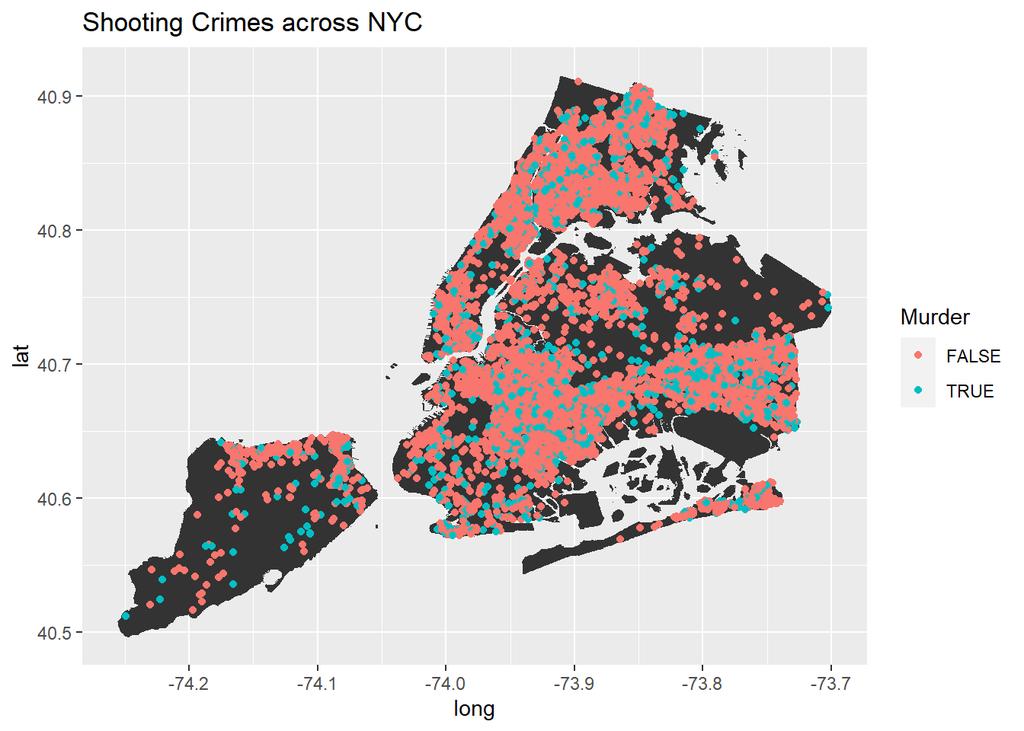

```r
nyc_neighborhoods_df <- tidy(nyc_neighborhoods)#load in our background map data and prepare it for ggplots
ggplot() +
  geom_polygon(data=nyc_neighborhoods_df, aes(x=long, y=lat, group=group))+#create ggplot background map layer of NYC
  geom_point(aes(x=nypd_coords$X1, y = nypd_coords$X2, color = nypd_coords$X3))+#plot our shooting incident points on the graph
  labs(color = "Murder")+
  ggtitle("Shooting Crimes across NYC")
```

The first visualization I produced was a map of crimes across New York City. This allows us to see where the most crimes happen. In blue, we see locations of murders while the red points show non murder shooting crimes. This map is really interesting showing us how shooting crimes are distributed throughout the city. We can see some differences by Neighborhood, with Staten Island having the least amount of shooting crimes. It appears that Northeast Brooklyn, Southern Queens, and the Bronx have the majority of shooting crimes. It would be interesting to explore these location based results with city information such as income and housing density.

### Age

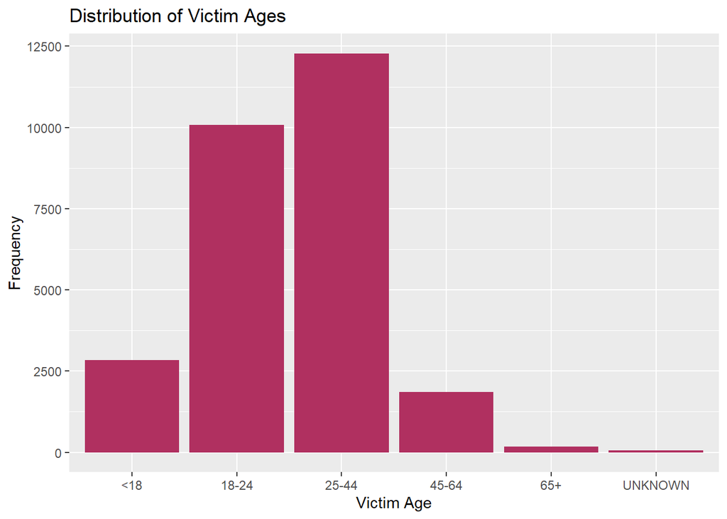

```r
filter(nypd, VIC_AGE_GROUP != 1022) %>%#create a bargraph in ggplot for the number of victims in shootings by race group
  ggplot()+
  geom_bar(aes(x = VIC_AGE_GROUP), fill = "maroon")+
  ggtitle("Distribution of Victim Ages")+
  labs(y = "Frequency", x = "Victim Age")
```

In this visual above, we can see how the victims are generally younger and between the ages of 18-44. Logically, this could be due to younger people being out more often or certain activities they are engaged in. It’s clear that as people age beyond 45, the frequency of shootings decreases vastly and there are very few shootings related to 65 year olds.

### Further Analysis on Victims

This section will explore a breakdown of demographics related to the victims of these shootings and based on whether a murder occurred or not.

```r
#create a table for victim age group by shooting outcome
prop.table(table(nypd[nypd$VIC_AGE_GROUP != 1022,]$STATISTICAL_MURDER_FLAG ,nypd[nypd$VIC_AGE_GROUP != 1022,]$VIC_AGE_GROUP), margin=1)
```

```
##
##                 <18        1022       18-24       25-44       45-64         65+
##   FALSE 0.111998186 0.000000000 0.381310955 0.435518258 0.063415741 0.005670220
##   TRUE  0.070262058 0.000000000 0.319027725 0.508925180 0.088302317 0.010634258
##
##             UNKNOWN
##   FALSE 0.002086641
##   TRUE  0.002848462
```

```r
#create a table for victim race by shooting outcome

prop.table(table(nypd$STATISTICAL_MURDER_FLAG ,nypd$VIC_RACE), margin=1)
```

```
##
##         AMERICAN INDIAN/ALASKAN NATIVE ASIAN / PACIFIC ISLANDER       BLACK
##   FALSE                    0.000453597              0.013743990 0.714732831
##   TRUE                     0.000000000              0.019179643 0.699202431
##
##         BLACK HISPANIC     UNKNOWN       WHITE WHITE HISPANIC
##   FALSE    0.100426381 0.002676222 0.022997369    0.144969609
##   TRUE     0.082035701 0.001329282 0.036270414    0.161982529
```

```r
#create a table for victim sex by shooting outcome

prop.table(table(nypd$STATISTICAL_MURDER_FLAG ,nypd$VIC_SEX), margin=1)
```

```
##
##                    F            M            U
##   FALSE 0.0944842602 0.9050621428 0.0004535970
##   TRUE  0.1010254463 0.8987846563 0.0001898975
```

### Time Analysis

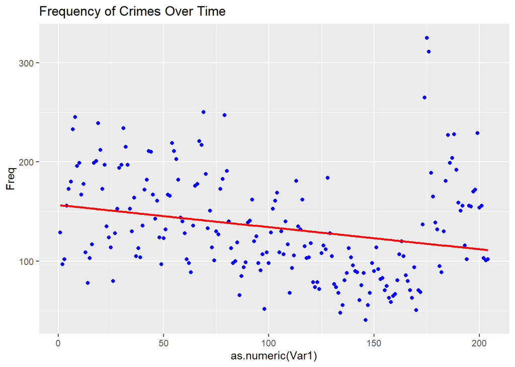

```r
nypd_dates <- nypd %>%
  mutate(
    newdate = format(OCCUR_DATE, "%Y-%m")
  )# create a month data variable instead of by day

date_count <- table(nypd_dates$newdate)#these two lines compile the frequency of crimes by month
dates <- as.data.frame(date_count)


dates%>%
ggplot(aes(x = as.numeric(Var1), y = Freq))+#plot the number of crimes per month by time
  geom_point(color = "blue")+
  geom_smooth(method = "lm", se = FALSE, color = "red")+#include a trend line
  ggtitle("Frequency of Crimes Over Time")
```

```r
summary(lm(Freq~as.numeric(Var1), dates))#linear regression line analysis for results
```

```
##
## Call:
## lm(formula = Freq ~ as.numeric(Var1), data = dates)
##
## Residuals:
##    Min     1Q Median     3Q    Max
## -83.20 -38.40 -11.89  35.59 207.25
##
## Coefficients:
##                   Estimate Std. Error t value Pr(>|t|)
## (Intercept)      156.69473    7.15690  21.894  < 2e-16 ***
## as.numeric(Var1)  -0.22256    0.06054  -3.676 0.000304 ***
## ---
## Signif. codes:  0 '***' 0.001 '**' 0.01 '*' 0.05 '.' 0.1 ' ' 1
##
## Residual standard error: 50.92 on 202 degrees of freedom
## Multiple R-squared:  0.0627, Adjusted R-squared:  0.05806
## F-statistic: 13.51 on 1 and 202 DF,  p-value: 0.0003035
```

This portion of the analysis examines the frequency of crimes by month over the span of this data set. Each month we compile the total number of shooting crimes and plot them over time. Now, we can examine the change in frequency of crimes over time and we do have supporting evidence that the number of crimes per month is actually decreasing over time (p <0.001).

### Bias

This analysis looked at locations of crimes, status of victims, and the rate of crime over time which may all have biases built in. First off, data reporting can vary vastly in its accuracy and availability in different areas. For example, data reporting may be very dependent on where police are located within the city, which could bias the results based on certain neighborhoods having more police presence and therefore more reporting, skewing results from less served areas. This can alter data and create misleading conclusions based upon data quality that is coming in. Additionally, bias can be created with the types of analysis and data cleaning choices we make as analysts. In this case, missing data was mostly excluded, and if the missing data had a common reason it was not available, this could create analysis quality issues. It is important to keep in mind data quality issues and make sure I am making analysis choices that are from a central point of view and keep in mind my implicit biases when performing data analysis.

Overall, this analysis looked at three main pieces in the data. First, we looked at the spread of crimes throughout NYC and saw that certain neighborhoods have significantly higher shooting rates, and even within neighborhoods, areas can have various rates of shooting incidents. We saw that Staten Island had the fewest shootings while certain areas in the Bronx, Queens, and Brooklyn had many occurrences of shooting crimes. Secondly, we looked at the demographics of victims in these shooting crimes, to conclude that most victims were African American, from younger age groups, and almost all victims being men. Lastly, I used a linear regression model to examine the number of crimes over time to find that shootings have decreased over the span of the data set, which is good news.